# Assignment 4: Tidy data and joins

# Exercise 1: Univariate Data Reshaping

## 1.1

Make a tibble with one row per year, and columns for life expectancy for two or more countries.

```r
gapwide <- gapminder %>%
  filter(country == "Afghanistan" | country == "Algeria") %>%
  pivot_wider(id_cols = year,
              names_from = country,
              values_from = lifeExp)
DT::datatable(gapwide)
```

|  | year | Afghanistan | Algeria |
| --- | --- | --- | --- |
| 1 | 1952 | 28.801 | 43.077 |
| 2 | 1957 | 30.332 | 45.685 |
| 3 | 1962 | 31.997 | 48.303 |
| 4 | 1967 | 34.02 | 51.407 |
| 5 | 1972 | 36.088 | 54.518 |
| 6 | 1977 | 38.438 | 58.014 |
| 7 | 1982 | 39.854 | 61.368 |
| 8 | 1987 | 40.822 | 65.799 |
| 9 | 1992 | 41.674 | 67.744 |
| 10 | 1997 | 41.763 | 69.152 |

[output cut: 2 more lines]

Now, the table above has successfully filtered out Afghanistan as well as Algeria and ordered them based on ascending year with a corresponding life expectancy (in years) for each year and country.

## 1.2

Take advantage of this new data shape to make a scatterplot of life expectancy of one country against that of another.

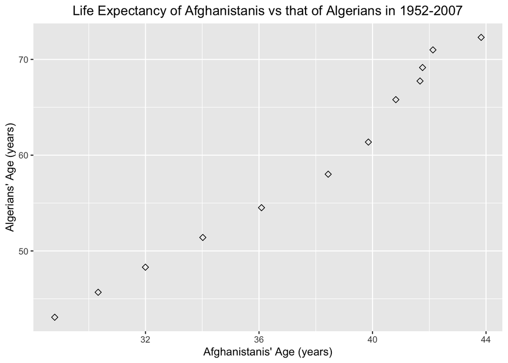

```r
gapwide %>%
  ggplot(aes(x=Afghanistan, y=Algeria)) +
  geom_point(size=2, shape=23) +
  labs(title = "Life Expectancy of Afghanistanis vs that of Algerians in 1952-2007",
       x = "Afghanistanis' Age (years)", y = "Algerians' Age (years)" ) +
  theme(plot.title = element_text(hjust = 0.5))
```

Overall, the trend depicted by the scatterplot above suggests that the Algerians generally have a higher life expectancy than the Afghans for each year in 1952 to 2007.

## 1.3

Re-lengthen the dataset

```r
gapwide %>%
  pivot_longer(cols = -year,
               names_to = "country",
               values_to = "life.exp") %>%
  arrange(country) %>%
  DT::datatable()
```

|  | year | country | life.exp |
| --- | --- | --- | --- |
| 1 | 1952 | Afghanistan | 28.801 |
| 2 | 1957 | Afghanistan | 30.332 |
| 3 | 1962 | Afghanistan | 31.997 |
| 4 | 1967 | Afghanistan | 34.02 |
| 5 | 1972 | Afghanistan | 36.088 |
| 6 | 1977 | Afghanistan | 38.438 |
| 7 | 1982 | Afghanistan | 39.854 |
| 8 | 1987 | Afghanistan | 40.822 |
| 9 | 1992 | Afghanistan | 41.674 |
| 10 | 1997 | Afghanistan | 41.763 |

[output cut: 14 more lines]

Now, we can reformat the table produced in 1.1 by making country a separate column with a corresponding year and life expectancy as shown above.

# Exercise 2: Multivariate Data Reshaping

## 2.1

Make a tibble with one row per year, and columns for life expectancy and GDP per capita (or two other numeric variables) for two or more countries.

```r
multigapwide <- gapminder %>%
  filter(country == "Afghanistan" | country == "Algeria") %>%
  pivot_wider(id_cols = year,
              names_from = country,
              values_from = c(gdpPercap, lifeExp))
DT::datatable(multigapwide)
```

|  | year | gdpPercap_Afghanistan | gdpPercap_Algeria | lifeExp_Afghanistan | lifeExp_Algeria |
| --- | --- | --- | --- | --- | --- |
| 1 | 1952 | 779.4453145 | 2449.008185 | 28.801 | 43.077 |
| 2 | 1957 | 820.8530296 | 3013.976023 | 30.332 | 45.685 |
| 3 | 1962 | 853.10071 | 2550.81688 | 31.997 | 48.303 |
| 4 | 1967 | 836.1971382 | 3246.991771 | 34.02 | 51.407 |
| 5 | 1972 | 739.9811058 | 4182.663766 | 36.088 | 54.518 |
| 6 | 1977 | 786.11336 | 4910.416756 | 38.438 | 58.014 |
| 7 | 1982 | 978.0114388 | 5745.160213 | 39.854 | 61.368 |
| 8 | 1987 | 852.3959448 | 5681.358539 | 40.822 | 65.799 |
| 9 | 1992 | 649.3413952 | 5023.216647 | 41.674 | 67.744 |
| 10 | 1997 | 635.341351 | 4797.295051 | 41.763 | 69.152 |

[output cut: 2 more lines]

First, we can filter by country, then obtain names from country and values from GDP per Capita and life expectancy from the selected countries.

We can discern from the table that GDP per Capita and life expectancy are separated and grouped with each country. All values are arranged chronologically based on the year column.

## 2.2

Re-lengthen the data.

```r
multigapwide %>%
  pivot_longer(cols = -year,
               names_to = c(".value", "country"),
               names_sep = "_" ) %>%
  arrange(country) %>%
  DT::datatable()
```

|  | year | country | gdpPercap | lifeExp |
| --- | --- | --- | --- | --- |
| 1 | 1952 | Afghanistan | 779.4453145 | 28.801 |
| 2 | 1957 | Afghanistan | 820.8530296 | 30.332 |
| 3 | 1962 | Afghanistan | 853.10071 | 31.997 |
| 4 | 1967 | Afghanistan | 836.1971382 | 34.02 |
| 5 | 1972 | Afghanistan | 739.9811058 | 36.088 |
| 6 | 1977 | Afghanistan | 786.11336 | 38.438 |
| 7 | 1982 | Afghanistan | 978.0114388 | 39.854 |
| 8 | 1987 | Afghanistan | 852.3959448 | 40.822 |
| 9 | 1992 | Afghanistan | 649.3413952 | 41.674 |
| 10 | 1997 | Afghanistan | 635.341351 | 41.763 |

[output cut: 14 more lines]

Instead of putting attributes of each country into different columns, we can actually create a country column and some columns of attributes of interest as shown above. The re-lengthened data is now grouped by country and year with corrresponding GDP per Capita and life expectancy information depicted beside it.

# Exercise 3: Table Joins

## 3.1

For each guest in the guestlist (guest tibble), add a column for email address, which can be found in the email tibble.

```r
emailnew <- separate_rows(email, guest, sep = ", ") %>%
  rename(name = guest) #separate guests' names and rename 'name' column

guest %>%
  left_join(emailnew, by = "name") %>%
  DT::datatable()
```

|  | party | name | meal_wedding | meal_brunch | attendance_wedding | attendance_brunch | attendance_golf | email |
| --- | --- | --- | --- | --- | --- | --- | --- | --- |
| 1 | 1 | Sommer Medrano | PENDING | PENDING | PENDING | PENDING | PENDING | sommm@gmail.com |
| 2 | 1 | Phillip Medrano | vegetarian | Menu C | CONFIRMED | CONFIRMED | CONFIRMED | sommm@gmail.com |
| 3 | 1 | Blanka Medrano | chicken | Menu A | CONFIRMED | CONFIRMED | CONFIRMED | sommm@gmail.com |
| 4 | 1 | Emaan Medrano | PENDING | PENDING | PENDING | PENDING | PENDING | sommm@gmail.com |
| 5 | 2 | Blair Park | chicken | Menu C | CONFIRMED | CONFIRMED | CONFIRMED | bpark@gmail.com |
| 6 | 2 | Nigel Webb |  |  | CANCELLED | CANCELLED | CANCELLED | bpark@gmail.com |
| 7 | 3 | Sinead English | PENDING | PENDING | PENDING | PENDING | PENDING | singlish@hotmail.ca |
| 8 | 4 | Ayra Marks | vegetarian | Menu B | PENDING | PENDING | PENDING | marksa42@gmail.com |
| 9 | 5 | Atlanta Connolly | PENDING | PENDING | PENDING | PENDING | PENDING |  |
| 10 | 5 | Denzel Connolly | fish | Menu B | CONFIRMED | CONFIRMED | CONFIRMED |  |

[output cut: 20 more lines]

Now, an email column with information extracted from the email dataset has been added into the guest dataset. Therefore, guests’ information can be accessed via examining one dataset instead of two.

## 3.2

Who do we have emails for, yet are not on the guestlist?

```r
emailnew %>%
  anti_join(guest, by = "name") %>%
  DT::datatable()
```

|  | name | email |
| --- | --- | --- |
| 1 | Turner Jones | tjjones12@hotmail.ca |
| 2 | Albert Marshall | themarshallfamily1234@gmail.com |
| 3 | Vivian Marshall | themarshallfamily1234@gmail.com |

Turner, Albert, and Vivian all have emails but not on the guestlist.

## 3.3

Make a guestlist that includes everyone we have emails for (in addition to those on the original guestlist).

```r
guest %>%
  full_join(emailnew, by = "name") %>%
  DT::datatable()
```

|  | party | name | meal_wedding | meal_brunch | attendance_wedding | attendance_brunch | attendance_golf | email |
| --- | --- | --- | --- | --- | --- | --- | --- | --- |
| 1 | 1 | Sommer Medrano | PENDING | PENDING | PENDING | PENDING | PENDING | sommm@gmail.com |
| 2 | 1 | Phillip Medrano | vegetarian | Menu C | CONFIRMED | CONFIRMED | CONFIRMED | sommm@gmail.com |
| 3 | 1 | Blanka Medrano | chicken | Menu A | CONFIRMED | CONFIRMED | CONFIRMED | sommm@gmail.com |
| 4 | 1 | Emaan Medrano | PENDING | PENDING | PENDING | PENDING | PENDING | sommm@gmail.com |
| 5 | 2 | Blair Park | chicken | Menu C | CONFIRMED | CONFIRMED | CONFIRMED | bpark@gmail.com |
| 6 | 2 | Nigel Webb |  |  | CANCELLED | CANCELLED | CANCELLED | bpark@gmail.com |
| 7 | 3 | Sinead English | PENDING | PENDING | PENDING | PENDING | PENDING | singlish@hotmail.ca |
| 8 | 4 | Ayra Marks | vegetarian | Menu B | PENDING | PENDING | PENDING | marksa42@gmail.com |
| 9 | 5 | Atlanta Connolly | PENDING | PENDING | PENDING | PENDING | PENDING |  |
| 10 | 5 | Denzel Connolly | fish | Menu B | CONFIRMED | CONFIRMED | CONFIRMED |  |

[output cut: 23 more lines]

By using `full_join()` to join the two datasets, we have created a guestlist with additional email information.